# Midterm

```r
matlambdas <- rbind(animals.eigen,propvar,cumvar)
rownames(matlambdas) <- c("Eigenvalues","Prop. variance","Cum. prop. variance")
round(matlambdas,4)
```

```
##                       [,1]   [,2]   [,3]   [,4]   [,5]   [,6]   [,7]   [,8]
## Eigenvalues         4.0936 1.5917 1.0813 0.9496 0.7004 0.5832 0.3848 0.3008
## Prop. variance      0.4094 0.1592 0.1081 0.0950 0.0700 0.0583 0.0385 0.0301
## Cum. prop. variance 0.4094 0.5685 0.6767 0.7716 0.8417 0.9000 0.9385 0.9686
##                       [,9]  [,10]
## Eigenvalues         0.2303 0.0841
## Prop. variance      0.0230 0.0084
## Cum. prop. variance 0.9916 1.0000
```

```r
summary(animals.PCA)
```

```
## Importance of components:
##                           PC1    PC2    PC3     PC4     PC5     PC6     PC7
## Standard deviation     2.0233 1.2616 1.0398 0.97446 0.83693 0.76370 0.62034
## Proportion of Variance 0.4094 0.1592 0.1081 0.09496 0.07004 0.05832 0.03848
## Cumulative Proportion  0.4094 0.5685 0.6767 0.77162 0.84166 0.89999 0.93847
##                            PC8     PC9    PC10
## Standard deviation     0.54848 0.47995 0.29007
## Proportion of Variance 0.03008 0.02303 0.00841
## Cumulative Proportion  0.96855 0.99159 1.00000
```

```r
animals.PCA$rotation
```

```
##                                                                PC1          PC2
## Recognition of Animal Sentience                         -0.3175379 -0.092399221
## Recognition of Animal Suffering                         -0.2483691 -0.470908880
## Any Laws Against Animal Cruelty                         -0.1100399 -0.581379087
## Support for the Universal Declaration of Animal Welfare -0.3871276  0.003127519
## Fur-Farming Ban                                         -0.3525993  0.203426783
## Meat Consumption per Capita in Kilograms                -0.3062785  0.401776564
## Percentage of Protected Areas                           -0.2360518 -0.161110907
## Kgs of Pesticide / Hectare of Cropland                  -0.1174138  0.340174969
## Environmental Performance Index Score                   -0.4207170  0.230670269
## Total Score                                             -0.4591991 -0.184402866
##                                                                 PC3
## Recognition of Animal Sentience                          0.25612805
## Recognition of Animal Suffering                         -0.27832108
## Any Laws Against Animal Cruelty                         -0.25979750
## Support for the Universal Declaration of Animal Welfare  0.26060070
## Fur-Farming Ban                                          0.28487665
## Meat Consumption per Capita in Kilograms                -0.16888405
## Percentage of Protected Areas                           -0.18249858
## Kgs of Pesticide / Hectare of Cropland                  -0.75723381
## Environmental Performance Index Score                   -0.05419629
## Total Score                                              0.04696588
##                                                                  PC4
## Recognition of Animal Sentience                         -0.547423487
## Recognition of Animal Suffering                         -0.281601275
## Any Laws Against Animal Cruelty                         -0.009685586
## Support for the Universal Declaration of Animal Welfare  0.190161605
## Fur-Farming Ban                                          0.276557116
## Meat Consumption per Capita in Kilograms                -0.296510924
## Percentage of Protected Areas                            0.641201533
## Kgs of Pesticide / Hectare of Cropland                   0.011546711
## Environmental Performance Index Score                   -0.056118296
## Total Score                                              0.077126128
##                                                                 PC5         PC6
## Recognition of Animal Sentience                         -0.34405658  0.03397628
## Recognition of Animal Suffering                         -0.09252402  0.42121087
## Any Laws Against Animal Cruelty                          0.45596303 -0.53226220
## Support for the Universal Declaration of Animal Welfare  0.21484275  0.36626071
## Fur-Farming Ban                                          0.39369244  0.02365529
## Meat Consumption per Capita in Kilograms                -0.16337913 -0.43718948
```

[output cut: 33 more lines]

```
## Percentage of Protected Areas                            0.115000462
## Kgs of Pesticide / Hectare of Cropland                   0.098672824
## Environmental Performance Index Score                   -0.742390014
## Total Score                                             -0.239752136
##                                                                PC10
## Recognition of Animal Sentience                          0.10929428
## Recognition of Animal Suffering                          0.24118386
## Any Laws Against Animal Cruelty                          0.08011652
## Support for the Universal Declaration of Animal Welfare  0.22549745
## Fur-Farming Ban                                          0.11697879
## Meat Consumption per Capita in Kilograms                -0.12530856
## Percentage of Protected Areas                            0.15737316
## Kgs of Pesticide / Hectare of Cropland                  -0.04496237
## Environmental Performance Index Score                    0.36586928
## Total Score                                             -0.82618571
```

```r
print(animals.PCA)
```

```
## Standard deviations (1, .., p=10):
##  [1] 2.0232622 1.2616391 1.0398386 0.9744647 0.8369253 0.7637013 0.6203448
##  [8] 0.5484806 0.4799458 0.2900709
##
## Rotation (n x k) = (10 x 10):
##                                                                PC1          PC2
## Recognition of Animal Sentience                         -0.3175379 -0.092399221
## Recognition of Animal Suffering                         -0.2483691 -0.470908880
## Any Laws Against Animal Cruelty                         -0.1100399 -0.581379087
## Support for the Universal Declaration of Animal Welfare -0.3871276  0.003127519
## Fur-Farming Ban                                         -0.3525993  0.203426783
## Meat Consumption per Capita in Kilograms                -0.3062785  0.401776564
## Percentage of Protected Areas                           -0.2360518 -0.161110907
## Kgs of Pesticide / Hectare of Cropland                  -0.1174138  0.340174969
## Environmental Performance Index Score                   -0.4207170  0.230670269
## Total Score                                             -0.4591991 -0.184402866
##                                                                 PC3
## Recognition of Animal Sentience                          0.25612805
## Recognition of Animal Suffering                         -0.27832108
## Any Laws Against Animal Cruelty                         -0.25979750
## Support for the Universal Declaration of Animal Welfare  0.26060070
## Fur-Farming Ban                                          0.28487665
## Meat Consumption per Capita in Kilograms                -0.16888405
## Percentage of Protected Areas                           -0.18249858
## Kgs of Pesticide / Hectare of Cropland                  -0.75723381
## Environmental Performance Index Score                   -0.05419629
## Total Score                                              0.04696588
##                                                                  PC4
## Recognition of Animal Sentience                         -0.547423487
## Recognition of Animal Suffering                         -0.281601275
## Any Laws Against Animal Cruelty                         -0.009685586
## Support for the Universal Declaration of Animal Welfare  0.190161605
## Fur-Farming Ban                                          0.276557116
## Meat Consumption per Capita in Kilograms                -0.296510924
## Percentage of Protected Areas                            0.641201533
## Kgs of Pesticide / Hectare of Cropland                   0.011546711
## Environmental Performance Index Score                   -0.056118296
## Total Score                                              0.077126128
##                                                                 PC5         PC6
## Recognition of Animal Sentience                         -0.34405658  0.03397628
```

[output cut: 38 more lines]

```
## Percentage of Protected Areas                            0.115000462
## Kgs of Pesticide / Hectare of Cropland                   0.098672824
## Environmental Performance Index Score                   -0.742390014
## Total Score                                             -0.239752136
##                                                                PC10
## Recognition of Animal Sentience                          0.10929428
## Recognition of Animal Suffering                          0.24118386
## Any Laws Against Animal Cruelty                          0.08011652
## Support for the Universal Declaration of Animal Welfare  0.22549745
## Fur-Farming Ban                                          0.11697879
## Meat Consumption per Capita in Kilograms                -0.12530856
## Percentage of Protected Areas                            0.15737316
## Kgs of Pesticide / Hectare of Cropland                  -0.04496237
## Environmental Performance Index Score                    0.36586928
## Total Score                                             -0.82618571
```

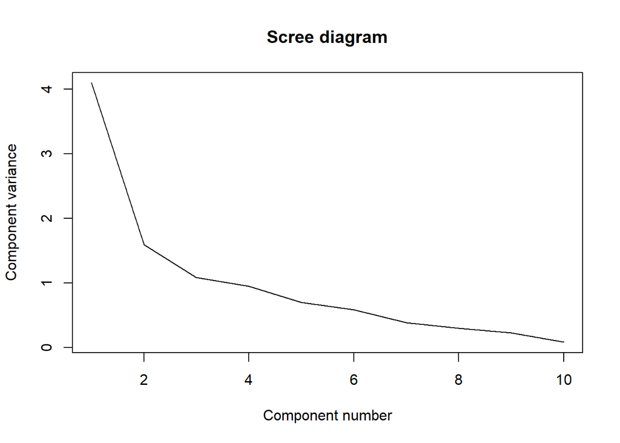

```r
plot(animals.eigen, xlab = "Component number", ylab = "Component variance", type = "l", main = "Scree diagram")
```

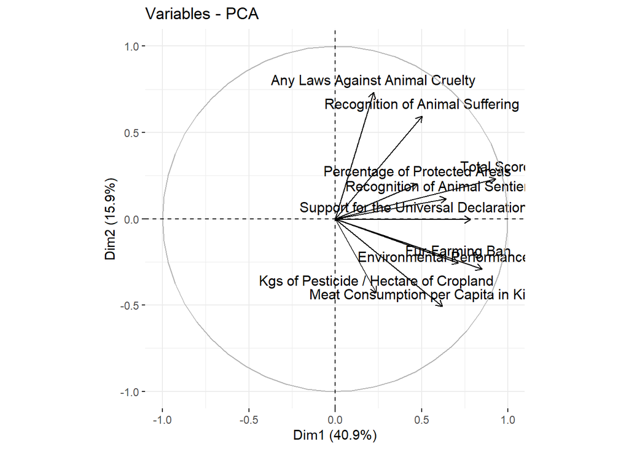

```r
#cutoff for PCA dimension's should be at 2 the elbow break is massive after 2 dimension's indicating that the variance dropp off is massive

res.pca <- PCA(Animal_Rights[-1], graph = FALSE)

fviz_pca_var(res.pca, col.var = "black")
```

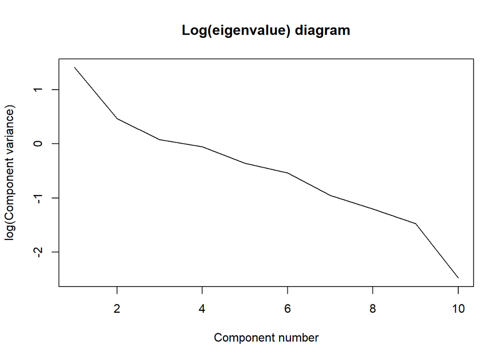

```r
plot(log(animals.eigen), xlab = "Component number",ylab = "log(Component variance)", type="l",main = "Log(eigenvalue) diagram")
```

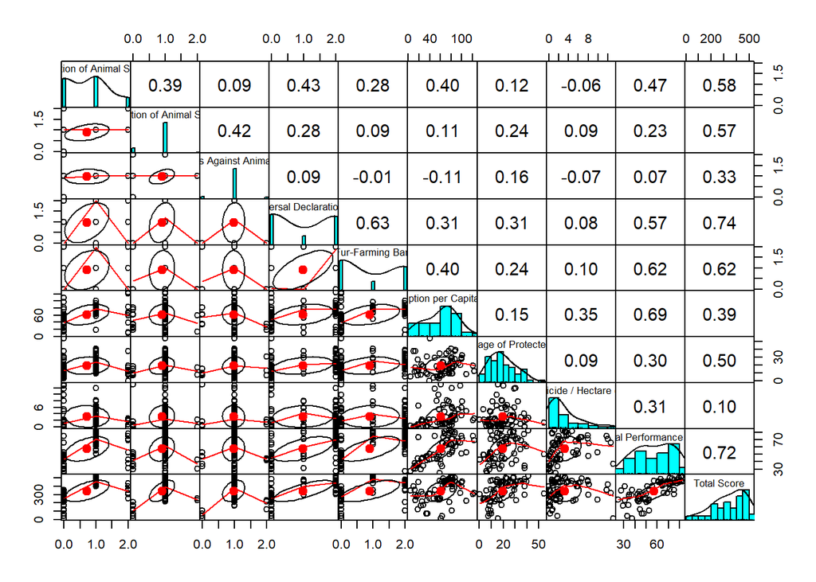

```r
# Correlation
pairs.panels(Animal_Rights[,-1],
             gap = 0,
             bg = c("red", "blue")[Animal_Rights$Country],
             pch=21)
```

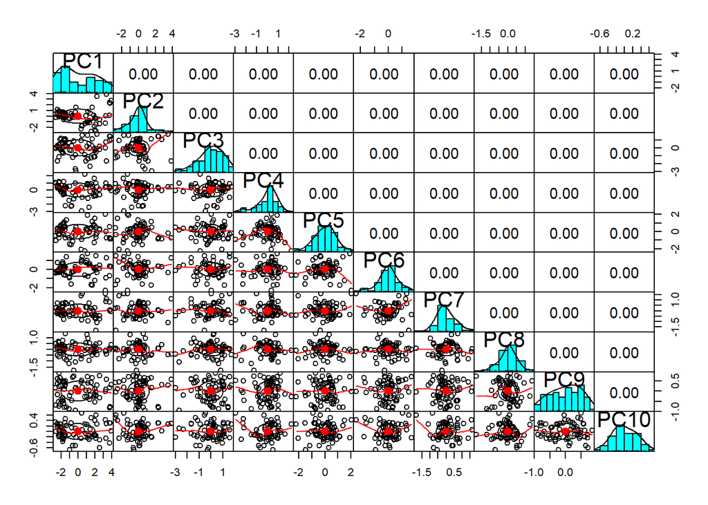

```r
pairs.panels(animals.PCA$x,
             gap=0,
             bg = c("red", "blue")[Animal_Rights$Country],
             pch=21)
```

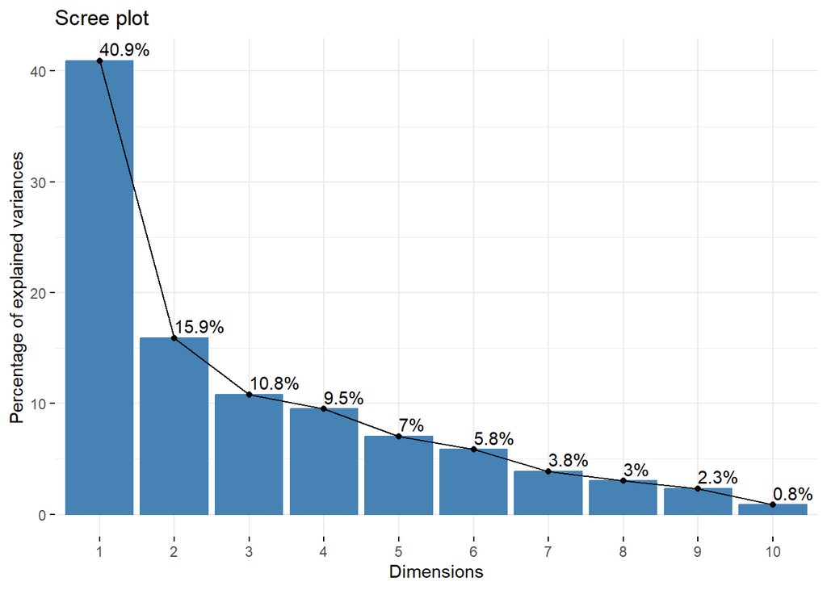

```r
# Variables - PCA (cos2)
fviz_eig(animals.PCA, addlabels = TRUE)
```

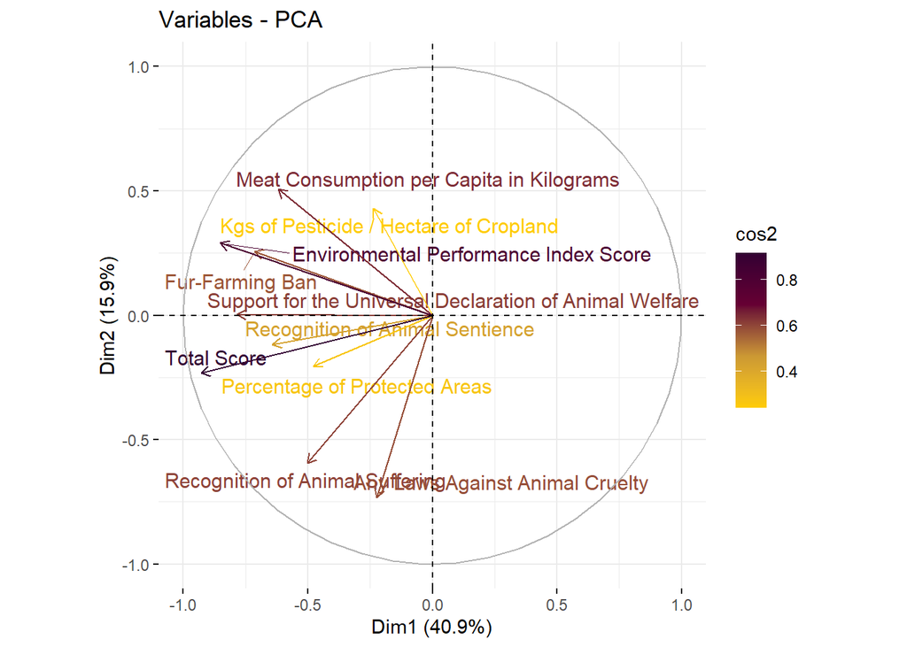

```r
fviz_pca_var(animals.PCA,col.var = "cos2",
             gradient.cols = c("#FFCC00", "#CC9933", "#660033", "#330033"),
             repel = TRUE)
```

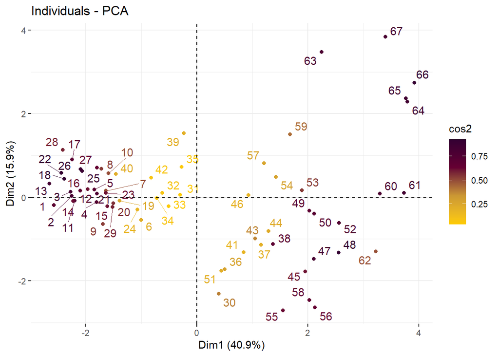

```r
# Individuals - PCA (cos2)
fviz_pca_ind(animals.PCA, col.ind = "cos2",
             gradient.cols = c("#FFCC00", "#CC9933", "#660033", "#330033"),
             repel = TRUE)
```

# Principal Component Analysis is used to reduce the large set of variables to a

# small set that still contains most of the information from the large dataset and thereby, reducing the dimension of the dataset.

# After performing PCA on the ANimal_rights Dataset, we obtain 10 Principal components.

# Each of these components represent the percentage of variability present in the dataset.

# In other words, PC1 explains 40.94% of total variance, PC2 explains 15.92% and so on.

# We will consider the first two principal components as they sum up to 57% of total variance

# and the others can be discarded as they contribute to only minimal amount of total variance.

```r
#   Identify the important factors underlying the observed variables and examine the relationships between the countries to these factors. Show visualizations to support your answers where possible.

# Note that here, we are excluding/ignoring the column 'total', because it is just having the summation of all the column values
fit.pc <- principal(Animal_Rights[c(-1,-11)], nfactors=6, rotate="varimax")
fit.pc
```

```
## Principal Components Analysis
## Call: principal(r = Animal_Rights[c(-1, -11)], nfactors = 6, rotate = "varimax")
## Standardized loadings (pattern matrix) based upon correlation matrix
##                                                          RC1   RC6   RC5   RC3
## Recognition of Animal Sentience                         0.21  0.53  0.67 -0.30
## Recognition of Animal Suffering                         0.09 -0.02  0.85  0.16
## Any Laws Against Animal Cruelty                         0.01 -0.03  0.18 -0.05
## Support for the Universal Declaration of Animal Welfare 0.85  0.12  0.30  0.01
## Fur-Farming Ban                                         0.88  0.27 -0.07  0.01
## Meat Consumption per Capita in Kilograms                0.17  0.89  0.04  0.21
## Percentage of Protected Areas                           0.16  0.09  0.09  0.03
## Kgs of Pesticide / Hectare of Cropland                  0.04  0.21  0.03  0.95
## Environmental Performance Index Score                   0.53  0.70  0.12  0.17
##                                                           RC2   RC4   h2     u2
## Recognition of Animal Sentience                         -0.08 -0.03 0.87 0.1308
## Recognition of Animal Suffering                          0.33  0.14 0.88 0.1230
## Any Laws Against Animal Cruelty                          0.97  0.07 0.97 0.0254
## Support for the Universal Declaration of Animal Welfare -0.01  0.14 0.84 0.1563
## Fur-Farming Ban                                          0.02  0.07 0.85 0.1486
## Meat Consumption per Capita in Kilograms                -0.08  0.05 0.88 0.1160
## Percentage of Protected Areas                            0.07  0.97 1.00 0.0041
## Kgs of Pesticide / Hectare of Cropland                  -0.05  0.03 0.95 0.0549
## Environmental Performance Index Score                    0.10  0.14 0.85 0.1452
##                                                         com
## Recognition of Animal Sentience                         2.6
## Recognition of Animal Suffering                         1.5
## Any Laws Against Animal Cruelty                         1.1
## Support for the Universal Declaration of Animal Welfare 1.4
## Fur-Farming Ban                                         1.2
## Meat Consumption per Capita in Kilograms                1.2
## Percentage of Protected Areas                           1.1
## Kgs of Pesticide / Hectare of Cropland                  1.1
## Environmental Performance Index Score                   2.2
##
##                        RC1  RC6  RC5  RC3  RC2  RC4
## SS loadings           1.88 1.71 1.32 1.09 1.07 1.02
## Proportion Var        0.21 0.19 0.15 0.12 0.12 0.11
## Cumulative Var        0.21 0.40 0.55 0.67 0.79 0.90
## Proportion Explained  0.23 0.21 0.16 0.13 0.13 0.13
## Cumulative Proportion 0.23 0.44 0.61 0.74 0.87 1.00
##
## Mean item complexity =  1.5
## Test of the hypothesis that 6 components are sufficient.
##
## The root mean square of the residuals (RMSR) is  0.05
##  with the empirical chi square  11.35  with prob <  NA
##
## Fit based upon off diagonal values = 0.98
```

```r
fit.pc <- principal(Animal_Rights[c(-1,-11)], nfactors=5, rotate="varimax")
fit.pc
```

```
## Principal Components Analysis
## Call: principal(r = Animal_Rights[c(-1, -11)], nfactors = 5, rotate = "varimax")
## Standardized loadings (pattern matrix) based upon correlation matrix
##                                                          RC1   RC5   RC2   RC3
## Recognition of Animal Sentience                         0.25  0.88  0.13 -0.10
## Recognition of Animal Suffering                         0.00  0.45  0.72  0.09
## Any Laws Against Animal Cruelty                         0.08 -0.10  0.90 -0.05
## Support for the Universal Declaration of Animal Welfare 0.80  0.23  0.15 -0.02
## Fur-Farming Ban                                         0.91  0.06 -0.04  0.07
## Meat Consumption per Capita in Kilograms                0.36  0.54 -0.19  0.56
## Percentage of Protected Areas                           0.19  0.04  0.11  0.06
## Kgs of Pesticide / Hectare of Cropland                  0.03 -0.09  0.04  0.93
## Environmental Performance Index Score                   0.67  0.42  0.04  0.42
##                                                          RC4   h2    u2 com
## Recognition of Animal Sentience                         0.02 0.87 0.132 1.2
## Recognition of Animal Suffering                         0.19 0.76 0.236 1.9
## Any Laws Against Animal Cruelty                         0.01 0.83 0.174 1.0
## Support for the Universal Declaration of Animal Welfare 0.18 0.75 0.250 1.3
## Fur-Farming Ban                                         0.06 0.85 0.150 1.0
## Meat Consumption per Capita in Kilograms                0.03 0.77 0.227 2.9
## Percentage of Protected Areas                           0.97 0.99 0.014 1.1
## Kgs of Pesticide / Hectare of Cropland                  0.04 0.88 0.116 1.0
## Environmental Performance Index Score                   0.12 0.82 0.184 2.5
##
##                        RC1  RC5  RC2  RC3  RC4
## SS loadings           2.16 1.53 1.42 1.39 1.02
## Proportion Var        0.24 0.17 0.16 0.15 0.11
## Cumulative Var        0.24 0.41 0.57 0.72 0.84
## Proportion Explained  0.29 0.20 0.19 0.18 0.14
## Cumulative Proportion 0.29 0.49 0.68 0.86 1.00
##
## Mean item complexity =  1.6
## Test of the hypothesis that 5 components are sufficient.
##
## The root mean square of the residuals (RMSR) is  0.07
##  with the empirical chi square  22.37  with prob <  2.2e-06
##
## Fit based upon off diagonal values = 0.95
```

```r
fit.pc <- principal(animals[c(-1,-11)], nfactors=4, rotate="varimax")
fit.pc
```

```
## Principal Components Analysis
## Call: principal(r = animals[c(-1, -11)], nfactors = 4, rotate = "varimax")
## Standardized loadings (pattern matrix) based upon correlation matrix
##       RC1   RC3   RC4   RC2   h2    u2 com
## fly -0.08 -0.07  0.98 -0.11 0.98 0.022 1.1
## ver  0.72  0.33 -0.24 -0.11 0.69 0.307 1.7
## end  0.92  0.00  0.04  0.01 0.85 0.149 1.0
## gro  0.14  0.97 -0.06  0.03 0.97 0.032 1.1
## hai -0.05  0.03 -0.11  0.99 0.99 0.008 1.0
##
##                        RC1  RC3  RC4  RC2
## SS loadings           1.40 1.05 1.03 1.00
## Proportion Var        0.28 0.21 0.21 0.20
## Cumulative Var        0.28 0.49 0.70 0.90
## Proportion Explained  0.31 0.24 0.23 0.22
## Cumulative Proportion 0.31 0.55 0.78 1.00
##
## Mean item complexity =  1.2
## Test of the hypothesis that 4 components are sufficient.
##
## The root mean square of the residuals (RMSR) is  0.09
##  with the empirical chi square  3  with prob <  NA
##
## Fit based upon off diagonal values = 0.84
```